# R Project

Adel

12/19/2020

Download nessary packages/libraries

```r
library("ggplot2")
library("ggthemes")
library("dplyr")
```

Download all data sets of the three cities.

```r
ny = read.csv('C:\\Users\\adela\\OneDrive\\Documents\\R DIr\\new-york-city.csv')
chi = read.csv('C:\\Users\\adela\\OneDrive\\Documents\\R DIr\\chicago.csv')
wash = read.csv('C:\\Users\\adela\\OneDrive\\Documents\\R DIr\\washington.csv')
```

Exploring data for each data set

```r
head(ny)
```

```
##         X      Start.Time        End.Time Trip.Duration           Start.Station
## 1 5688089 6/11/2017 14:55 6/11/2017 15:08           795 Suffolk St & Stanton St
## 2 4096714 5/11/2017 15:30 5/11/2017 15:41           692 Lexington Ave & E 63 St
## 3 2173887 3/29/2017 13:26 3/29/2017 13:48          1325       1 Pl & Clinton St
## 4 3945638  5/8/2017 19:47  5/8/2017 19:59           703   Barrow St & Hudson St
## 5 6208972  6/21/2017 7:49  6/21/2017 7:54           329         1 Ave & E 44 St
## 6 1285652 2/22/2017 18:55 2/22/2017 19:12           998     State St & Smith St
##              End.Station  User.Type Gender Birth.Year
## 1 W Broadway & Spring St Subscriber   Male       1998
## 2        1 Ave & E 78 St Subscriber   Male       1981
## 3   Henry St & Degraw St Subscriber   Male       1987
## 4        W 20 St & 8 Ave Subscriber Female       1986
## 5        E 53 St & 3 Ave Subscriber   Male       1992
## 6    Bond St & Fulton St Subscriber   Male       1986
```

```r
head(chi)
```

```
##         X      Start.Time        End.Time Trip.Duration
## 1 1423854 6/23/2017 15:09 6/23/2017 15:14           321
## 2  955915 5/25/2017 18:19 5/25/2017 18:45          1610
## 3    9031   1/4/2017 8:27   1/4/2017 8:34           416
## 4  304487  3/6/2017 13:49  3/6/2017 13:55           350
## 5   45207 1/17/2017 14:53 1/17/2017 15:02           534
## 6 1473887  6/26/2017 9:01  6/26/2017 9:11           586
##                   Start.Station                  End.Station  User.Type Gender
## 1          Wood St & Hubbard St      Damen Ave & Chicago Ave Subscriber   Male
## 2           Theater on the Lake Sheffield Ave & Waveland Ave Subscriber Female
## 3            May St & Taylor St          Wood St & Taylor St Subscriber   Male
## 4 Christiana Ave & Lawrence Ave St. Louis Ave & Balmoral Ave Subscriber   Male
## 5        Clark St & Randolph St Desplaines St & Jackson Blvd Subscriber   Male
## 6  Clinton St & Washington Blvd         Canal St & Taylor St Subscriber   Male
##   Birth.Year
## 1       1992
## 2       1992
## 3       1981
## 4       1986
## 5       1975
## 6       1990
```

```r
head(wash)
```

```
##         X      Start.Time        End.Time Trip.Duration
## 1 1621326  6/21/2017 8:36  6/21/2017 8:44       489.066
## 2  482740 3/11/2017 10:40 3/11/2017 10:46       402.549
## 3 1330037  5/30/2017 1:02  5/30/2017 1:13       637.251
## 4  665458   4/2/2017 7:48   4/2/2017 8:19      1827.341
## 5 1481135  6/10/2017 8:36  6/10/2017 9:02      1549.427
## 6 1148202  5/14/2017 7:18  5/14/2017 7:24       398.000
##                                 Start.Station
## 1                        14th & Belmont St NW
## 2                  Yuma St & Tenley Circle NW
## 3              17th St & Massachusetts Ave NW
## 4            Constitution Ave & 2nd St NW/DOL
## 5 Henry Bacon Dr & Lincoln Memorial Circle NW
## 6                               1st & K St SE
##                                           End.Station  User.Type
## 1                                      15th & K St NW Subscriber
## 2                        Connecticut Ave & Yuma St NW Subscriber
## 3                                       5th & K St NW Subscriber
## 4                          M St & Pennsylvania Ave NW   Customer
## 5                               Maine Ave & 7th St SW Subscriber
## 6 Eastern Market Metro / Pennsylvania Ave & 7th St SE Subscriber
```

Q1: Does Gender influence the type of rider in New York?

Running a descriptive summary to understanding the data

```r
summary(ny)
```

```
##        X                     Start.Time                End.Time
##  Min.   :     33   5/10/2017 18:14:    15   6/28/2017 18:48:    15
##  1st Qu.:1707416   5/23/2017 17:41:    14   5/17/2017 18:21:    14
##  Median :3405756   6/15/2017 17:43:    14   6/14/2017 17:49:    14
##  Mean   :3407026   6/22/2017 17:37:    14   6/20/2017 18:38:    14
##  3rd Qu.:5108762   6/22/2017 18:20:    14   4/29/2017 13:06:    13
##  Max.   :6816152   6/26/2017 18:10:    14   5/1/2017 18:35 :    13
##                    (Other)        :299915   (Other)        :299917
##  Trip.Duration                     Start.Station
##  Min.   :     61.0   Pershing Square North:  3069
##  1st Qu.:    368.0   E 17 St & Broadway   :  2089
##  Median :    609.0   Broadway & E 22 St   :  2082
##  Mean   :    899.7   W 21 St & 6 Ave      :  2019
##  3rd Qu.:   1054.0   West St & Chambers St:  1968
##  Max.   :2155775.0   W 20 St & 11 Ave     :  1743
##                      (Other)              :287030
##                 End.Station          User.Type         Gender
##  Pershing Square North:  3077             :   692         : 29209
##  Broadway & E 22 St   :  2343   Customer  : 30159   Female: 66783
##  E 17 St & Broadway   :  2316   Subscriber:269149   Male  :204008
##  W 21 St & 6 Ave      :  2036
##  West St & Chambers St:  1968
##  W 20 St & 11 Ave     :  1932
##  (Other)              :286328
##    Birth.Year
##  Min.   :1885
##  1st Qu.:1970
##  Median :1981
##  Mean   :1978
##  3rd Qu.:1988
##  Max.   :2001
##  NA's   :28220
```

The summary showed that both Gender and User Type have blank cells which seem to be missing values.Ploting User type by Gender in New York using barcharts:

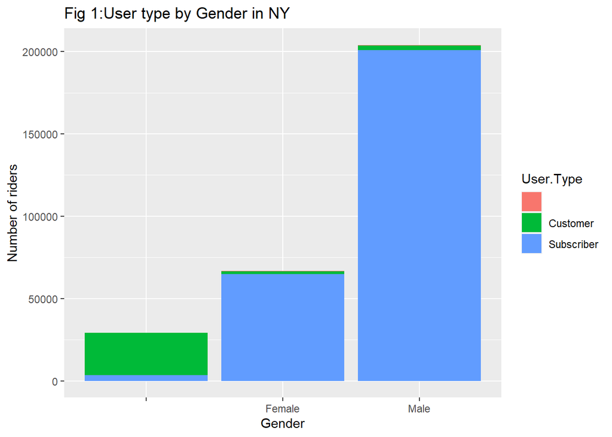

```r
ggplot(data= ny, aes(x= Gender, fill = User.Type))+geom_bar(position = 'stack') + ylab('Number of riders')+ggtitle('Fig 1:User type by Gender in NY')
```

As the graph confirms our findings above with regards to variables of interest, Choice is made to consider the blank cells as NA’s.

```r
ny$Gender[ny$Gender==""] <-NA
ny$User.Type[ny$User.Type ==""] <-NA
```

Now , Let’s plot gain the distribution of User type by gender without missing values (excluding NA’s) to get a more clearer picture.

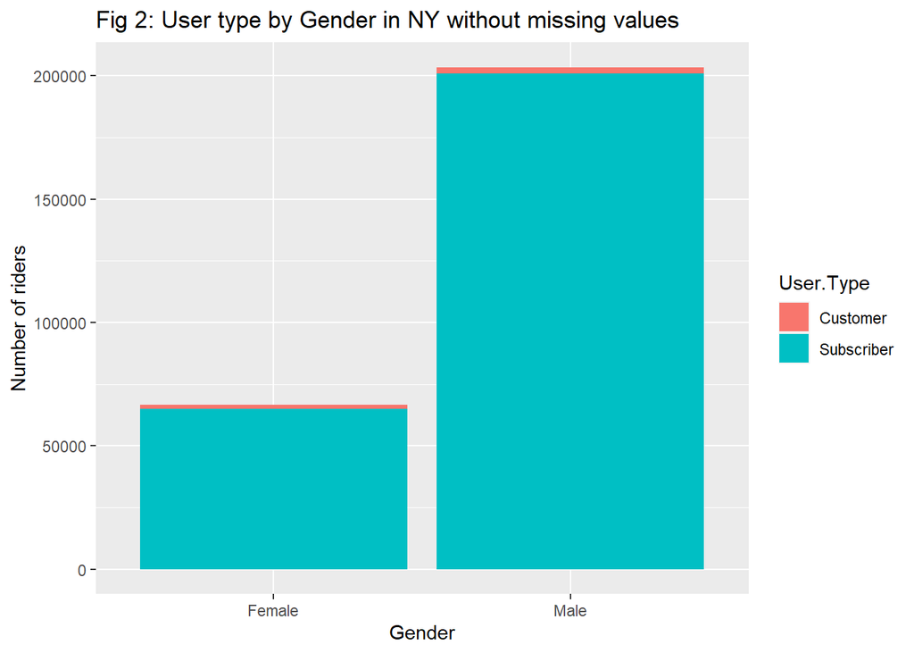

```r
ny %>%
  filter(!is.na(Gender) & !is.na(User.Type)) %>%
  ggplot(aes(x = Gender, fill = User.Type))+
  geom_bar(position = "stack") +
  ylab('Number of riders') +
  ggtitle("Fig 2: User type by Gender in NY without missing values")
```

Running a compute a summary table to represent the total counts of customers and suscribers according to their gender.

```r
ny2 <-ny %>%
  filter(!is.na(Gender) & !is.na(User.Type))

by( ny2$User.Type ,ny2$Gender , summary)
```

```
## ny2$Gender:
## NULL
## ------------------------------------------------------------
## ny2$Gender: Female
##              Customer Subscriber
##          0       1713      64859
## ------------------------------------------------------------
## ny2$Gender: Male
##              Customer Subscriber
##          0       2652     200887
```

Performing a chi-square statistic test to establish wether Gender and user type are asociated? #H0: Gender and user type are independent #H1: Gender and usere type are related

```r
chisq.test(ny2$Gender, ny2$User.Type, correct =FALSE)
```

```
##
##  Pearson's Chi-squared test
##
## data:  ny2$Gender and ny2$User.Type
## X-squared = 509.07, df = 1, p-value < 2.2e-16
```

since the P-value is less than 0.05 , we can conclude that there is a relationship between Gender and User Type.

Q2:What are the counts of each gender (only available for NYC and Chicago)?

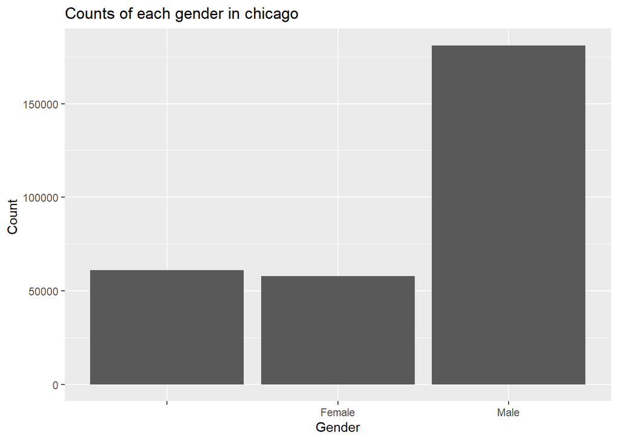

```r
chi %>% group_by(Gender) %>% filter(!is.na(Gender))%>%
  summarise(total = length(Gender))%>%
  ggplot(aes(Gender, total)) + geom_bar(stat = 'identity')+
  xlab("Gender") +  ylab("Count ")+ ggtitle("Counts of each gender in chicago")
```

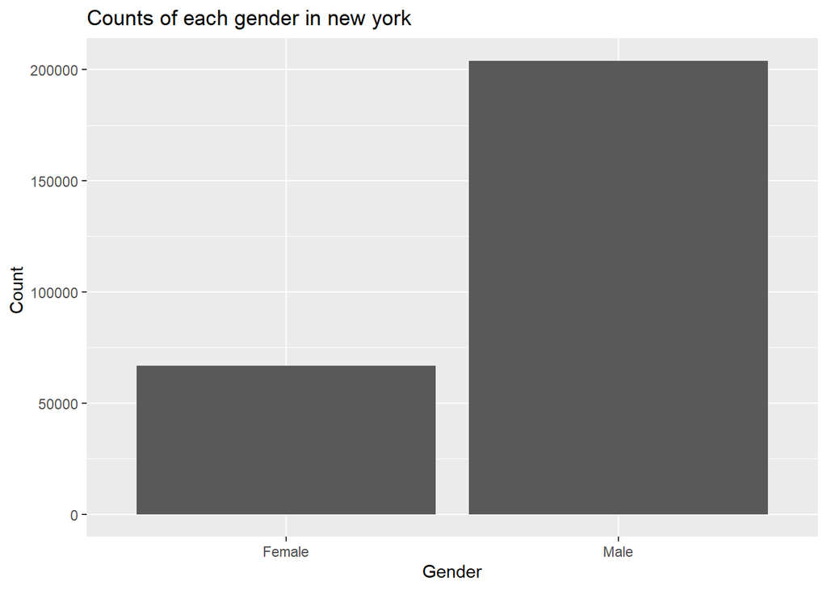

```r
ny %>% group_by(Gender) %>% filter(!is.na(Gender))%>%
  summarise(total = length(Gender))%>%
  ggplot(aes(Gender, total)) + geom_bar(stat = 'identity')+
  xlab("Gender") +  ylab("Count ")+ ggtitle("Counts of each gender in new york")
```

Q3:What is the gender wise median travel time for users in different cities ?

```r
summary(chi$Trip.Duration)
```

```
##    Min. 1st Qu.  Median    Mean 3rd Qu.    Max.
##    60.0   393.0   670.0   936.2  1125.0 86224.0
```

Median trip duration in chicago is 670.0 seconds and Mean trip duration is 936.2 seconds.

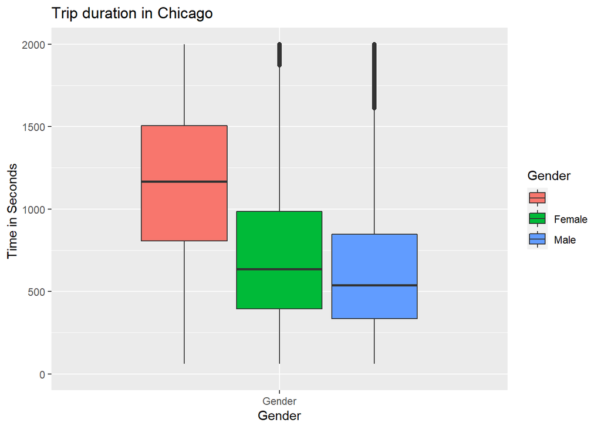

```r
ggplot(data = subset(chi, !is.na(Gender)), aes("Gender",Trip.Duration, fill = Gender)) + geom_boxplot()+
  scale_y_continuous(limits = c(0,2000))+
  xlab("Gender") +  ylab("Time in Seconds ")+ ggtitle("Trip duration in Chicago")
```

```r
summary(ny$Trip.Duration)
```

```
##      Min.   1st Qu.    Median      Mean   3rd Qu.      Max.
##      61.0     368.0     609.0     899.7    1054.0 2155775.0
```

Median trip duration in newyork is 609.0 seconds and Mean trip duration is 899.7 seconds.

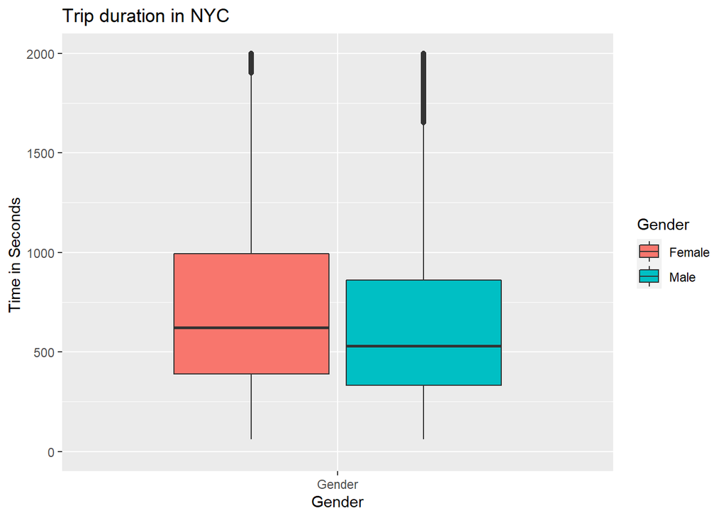

```r
ggplot(data = subset(ny, !is.na(Gender)), aes("Gender",Trip.Duration, fill = Gender)) + geom_boxplot()+
  scale_y_continuous(limits = c(0,2000))+
  xlab("Gender") +  ylab("Time in Seconds ")+ ggtitle("Trip duration in NYC")
```